# Assignment 5

## Exercise 4

In Assignment 2, I created a histogram of life expectancies from 2007. In this exercise, I will modify the graph to change the binwidth and change the colour so that red shows a high density, and green shows a low density. Also, I will superimpose a density curve on top of it.

Here is my original plot:

```r
lifeExp2007 <- gapminder %>%
  select(country, lifeExp, year) %>%
  filter(year == 2007)
lifeExp2007
```

| country | lifeExp | year |
| --- | --- | --- |
| Afghanistan | 43.828 | 2007 |
| Albania | 76.423 | 2007 |
| Algeria | 72.301 | 2007 |
| Angola | 42.731 | 2007 |
| Argentina | 75.320 | 2007 |
| Australia | 81.235 | 2007 |
| Austria | 79.829 | 2007 |
| Bahrain | 75.635 | 2007 |
| Bangladesh | 64.062 | 2007 |
| Belgium | 79.441 | 2007 |

[output cut: 132 more lines]

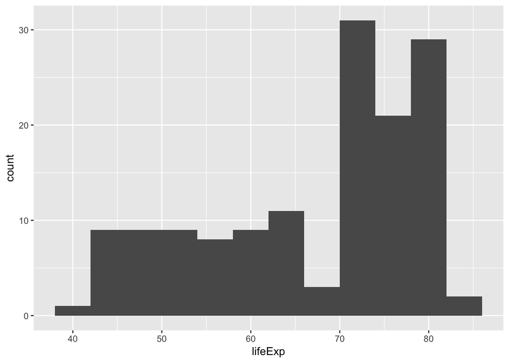

```r
plot1 <- lifeExp2007 %>%
  select(lifeExp) %>%
  ggplot(aes(lifeExp)) +
  geom_histogram(binwidth = 4)
plot1
```

Now, I will change it to add all the stuff I mentioned above. Here is the new plot:

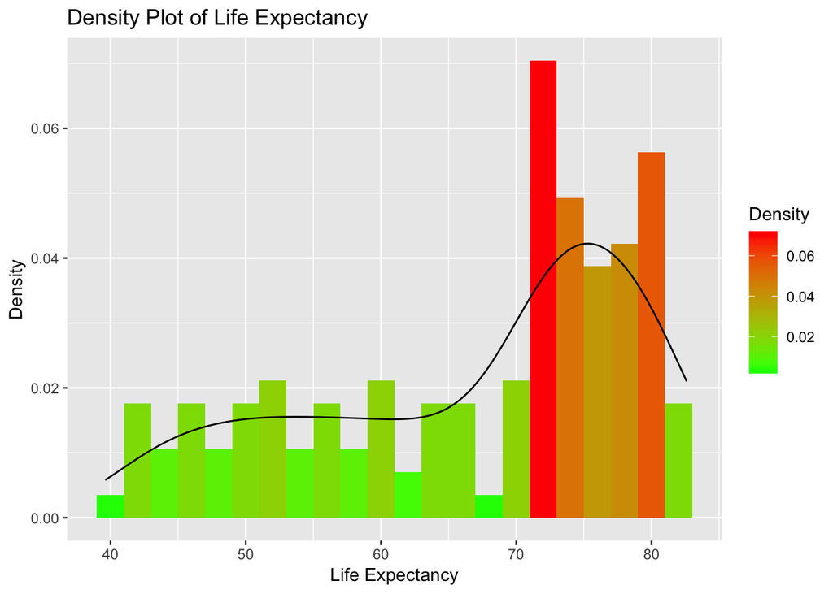

```r
plot2 <- lifeExp2007 %>%
  select(lifeExp) %>%
  ggplot(aes(lifeExp, y=..density..)) +
  geom_histogram(binwidth = 2, aes(fill=..density..)) +
  scale_fill_gradient("Density", low="green", high="red") +
  geom_line(stat="density", color="black") +
  ylab("Density") +
  xlab("Life Expectancy") +
  ggtitle("Density Plot of Life Expectancy")
plot2
```

Plotting these side-by-side, we can see a big improvement!

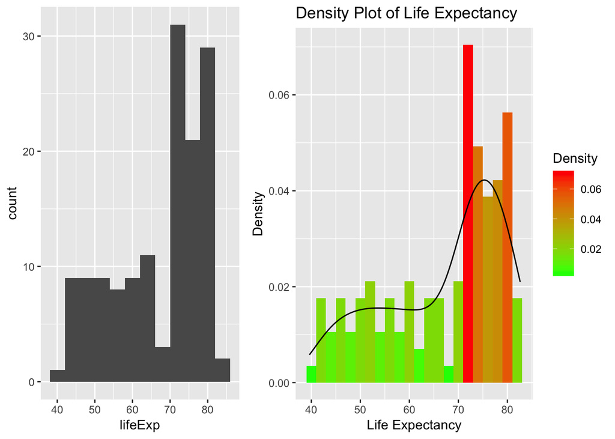

```r
gridExtra::grid.arrange(plot1, plot2, ncol=2,
                        widths = c(2,3))
```